# Homework: Univariate Regression

Your Name

2025-11-10

# Load Data

```r
# Load the dataset
cars_data <- read.csv("used-cars_2cities_prep.csv")

# Display structure of the data
str(cars_data)
```

```
## 'data.frame':    549 obs. of  23 variables:
##  $ pricestr    : chr  "$4990" "$10625" "$14850" "$15630" ...
##  $ area        : chr  "chicago" "chicago" "chicago" "chicago" ...
##  $ subarea     : chr  "chicago city" "chicago city" "chicago city" "chicago city" ...
##  $ name        : chr  "2007 Toyota Camry Hybrid" "2009 Toyota Camry Hybrid" "2015 Toyota_ Camry_" "2016 TOYOTA CAMRY" ...
##  $ condition   : chr  "good" NA "excellent" NA ...
##  $ cylinders   : chr  "4 cylinders" "4 cylinders" "other" NA ...
##  $ drive       : chr  "fwd" "fwd" NA "fwd" ...
##  $ fuel        : chr  "gas" "hybrid" "gas" "gas" ...
##  $ odometer    : num  11.62 4.37 3.57 1.32 18.7 ...
##  $ paintcolor  : chr  "grey" "grey" NA NA ...
##  $ size        : chr  NA NA NA NA ...
##  $ transmission: chr  "automatic" "automatic" "automatic" "automatic" ...
##  $ type        : chr  "sedan" "sedan" "sedan" "sedan" ...
##  $ dealer      : int  1 1 1 1 0 0 0 0 0 0 ...
##  $ price       : int  4990 10625 14850 15630 850 1300 1600 1500 1650 2295 ...
##  $ lnprice     : num  8.52 9.27 9.61 9.66 6.75 ...
##  $ year        : int  2007 2009 2015 2016 1993 1998 1998 1998 1999 2000 ...
##  $ age         : int  11 9 3 2 25 20 20 20 19 18 ...
##  $ lnodometer  : num  2.453 1.475 1.273 0.274 2.929 ...
##  $ LE          : int  0 0 0 0 0 0 1 0 0 1 ...
##  $ XLE         : int  0 0 0 0 0 0 0 0 0 0 ...
##  $ SE          : int  0 0 0 0 0 0 0 0 0 0 ...
##  $ Hybrid      : int  1 1 0 0 0 0 0 0 0 0 ...
```

```r
head(cars_data)
```

```
##   pricestr    area      subarea                     name condition   cylinders
## 1    $4990 chicago chicago city 2007 Toyota Camry Hybrid      good 4 cylinders
## 2   $10625 chicago chicago city 2009 Toyota Camry Hybrid      <NA> 4 cylinders
## 3   $14850 chicago chicago city      2015 Toyota_ Camry_ excellent       other
## 4   $15630 chicago chicago city        2016 TOYOTA CAMRY      <NA>        <NA>
## 5     $850 chicago chicago city        1993 toyota camry      good 6 cylinders
## 6    $1300 chicago chicago city        1998 toyota camry      fair 4 cylinders
##   drive   fuel odometer paintcolor      size transmission  type dealer price
## 1   fwd    gas 11.62360       grey      <NA>    automatic sedan      1  4990
## 2   fwd hybrid  4.37020       grey      <NA>    automatic sedan      1 10625
## 3  <NA>    gas  3.57210       <NA>      <NA>    automatic sedan      1 14850
## 4   fwd    gas  1.31520       <NA>      <NA>    automatic sedan      1 15630
## 5   fwd    gas 18.70000        red full-size    automatic sedan      0   850
## 6   fwd    gas 16.82426       grey      <NA>    automatic  <NA>      0  1300
##    lnprice year age lnodometer LE XLE SE Hybrid
## 1 8.515191 2007  11  2.4530375  0   0  0      1
## 2 9.270965 2009   9  1.4748088  0   0  0      1
## 3 9.605755 2015   3  1.2731537  0   0  0      0
## 4 9.656947 2016   2  0.2739888  0   0  0      0
## 5 6.745236 1993  25  2.9285235  0   0  0      0
## 6 7.170120 1998  20  2.8228219  0   0  0      0
```

# Task 1: Relationship Between Car Age and Price

**What kind of relationship do you think exists between these two variables, and why?**

I expect a **negative relationship** between car age and price. As cars get older, they typically depreciate in value due to:

- Increased wear and tear
- Higher mileage
- Outdated technology and features
- Higher maintenance costs
- Lower reliability concerns

Therefore, older cars should generally have lower prices than newer cars.

# Task 2: Initial Regression (Before Cleaning)

```r
# Run initial regression before removing extreme values
model_initial <- lm(price ~ age, data = cars_data)
summary(model_initial)
```

```
##
## Call:
## lm(formula = price ~ age, data = cars_data)
##
## Residuals:
##    Min     1Q Median     3Q    Max
## -12029  -1457   -223   1110  85778
##
## Coefficients:
##             Estimate Std. Error t value Pr(>|t|)
## (Intercept) 12972.99     441.82   29.36   <2e-16 ***
## age          -583.29      32.66  -17.86   <2e-16 ***
## ---
## Signif. codes:  0 '***' 0.001 '**' 0.01 '*' 0.05 '.' 0.1 ' ' 1
##
## Residual standard error: 4501 on 547 degrees of freedom
## Multiple R-squared:  0.3684, Adjusted R-squared:  0.3672
## F-statistic:   319 on 1 and 547 DF,  p-value: < 2.2e-16
```

**Interpretation of coefficients:**

- **Intercept (β₀):** 1.297299^{4} - This represents the predicted price (in USD) of a car with age = 0 (a brand new car).
- **Slope (β₁):** -583.29 - For each additional year of age, the car price decreases by approximately 583.29 USD on average.

# Task 3: Check for Extreme Values in Price

```r
# Examine price distribution
summary(cars_data$price)
```

```
##    Min. 1st Qu.  Median    Mean 3rd Qu.    Max.
##       1    2400    4300    5866    8299   90002
```

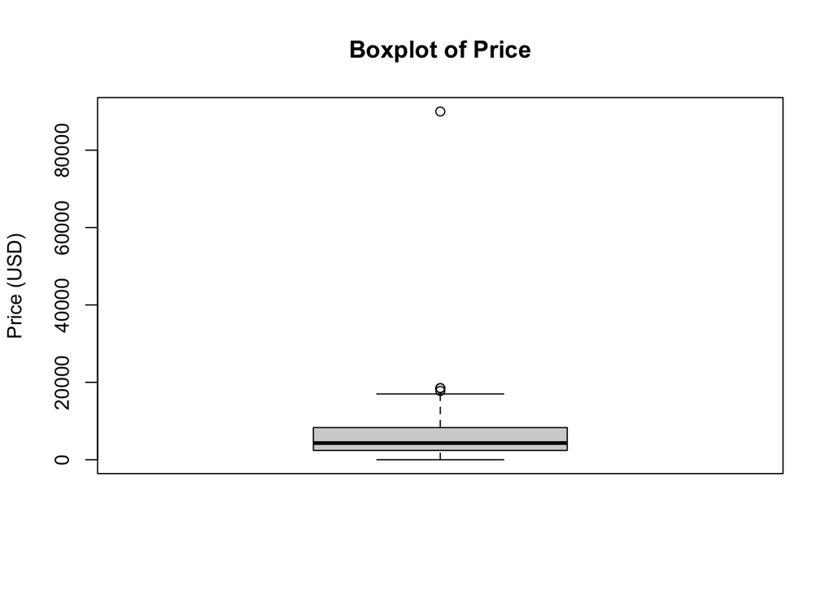

```r
# Visualize potential outliers using boxplot
boxplot(cars_data$price, main = "Boxplot of Price", ylab = "Price (USD)")
```

```r
# Calculate IQR and identify outliers
Q1 <- quantile(cars_data$price, 0.25)
Q3 <- quantile(cars_data$price, 0.75)
IQR_price <- Q3 - Q1

# Define outlier bounds (1.5 * IQR rule)
lower_bound <- Q1 - 1.5 * IQR_price
upper_bound <- Q3 + 1.5 * IQR_price

cat("Lower bound:", lower_bound, "\n")
```

```
## Lower bound: -6448.5
```

```r
cat("Upper bound:", upper_bound, "\n")
```

```
## Upper bound: 17147.5
```

```r
# Count outliers
outliers <- cars_data %>%
  filter(price < lower_bound | price > upper_bound)

cat("\nNumber of extreme values:", nrow(outliers), "\n")
```

```
##
## Number of extreme values: 4
```

```r
# Remove extreme values
cars_clean <- cars_data %>%
  filter(price >= lower_bound & price <= upper_bound)

cat("Original observations:", nrow(cars_data), "\n")
```

```
## Original observations: 549
```

```r
cat("After removing extremes:", nrow(cars_clean), "\n")
```

```
## After removing extremes: 545
```

```r
cat("Observations removed:", nrow(cars_data) - nrow(cars_clean), "\n")
```

```
## Observations removed: 4
```

**Explanation:**

I used the **IQR (Interquartile Range) method** to identify extreme values. Values below Q1 - 1.5×IQR or above Q3 + 1.5×IQR are considered outliers. I removed **4 observations** that had extreme price values. These extreme values could represent data entry errors, luxury vehicles, or special cases that don’t represent typical used car prices and could distort our regression analysis.

# Task 4: Descriptive Statistics and Histogram

```r
# Calculate descriptive statistics for price
mean_price <- mean(cars_clean$price)
median_price <- median(cars_clean$price)
sd_price <- sd(cars_clean$price)

cat("Mean price:", round(mean_price, 2), "USD\n")
```

```
## Mean price: 5643.57 USD
```

```r
cat("Median price:", round(median_price, 2), "USD\n")
```

```
## Median price: 4100 USD
```

```r
cat("Standard deviation:", round(sd_price, 2), "USD\n")
```

```
## Standard deviation: 4281.95 USD
```

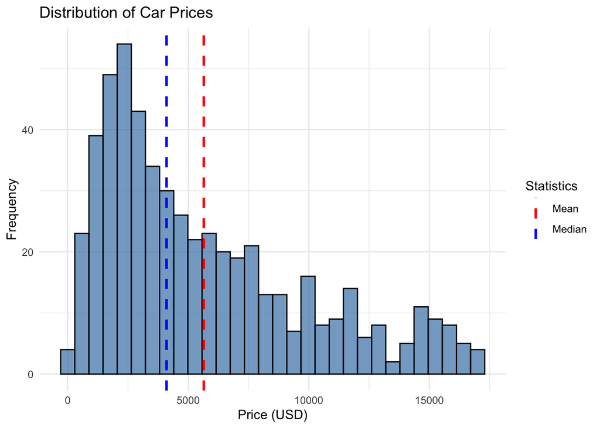

```r
# Create histogram
ggplot(cars_clean, aes(x = price)) +
  geom_histogram(bins = 30, fill = "steelblue", color = "black", alpha = 0.7) +
  geom_vline(aes(xintercept = mean_price, color = "Mean"),
             linetype = "dashed", size = 1) +
  geom_vline(aes(xintercept = median_price, color = "Median"),
             linetype = "dashed", size = 1) +
  scale_color_manual(values = c("Mean" = "red", "Median" = "blue")) +
  labs(title = "Distribution of Car Prices",
       x = "Price (USD)",
       y = "Frequency",
       color = "Statistics") +
  theme_minimal()
```

**Interpretation:**

- **Mean:** 5643.57 USD - the average car price
- **Median:** 4100 USD - the middle value, suggesting that 50% of cars are priced below this value
- **Standard deviation:** 4281.95 USD - indicates the typical deviation from the mean

The histogram shows the distribution is **right-skewed** (if mean > median), meaning there are more lower-priced cars with some higher-priced vehicles pulling the mean upward. The distribution appears to be concentrated in the lower to middle price range.

# Task 5: Scatter Plot of Price vs Age

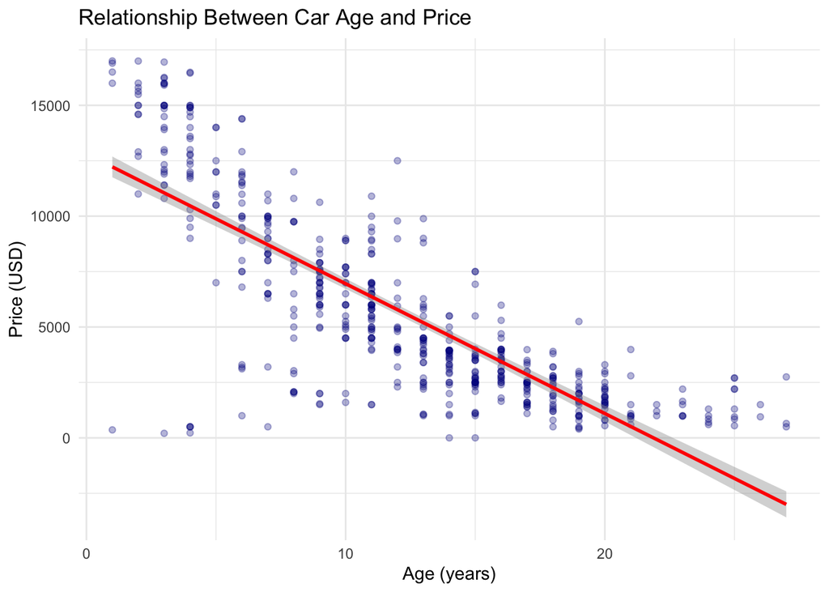

```r
ggplot(cars_clean, aes(x = age, y = price)) +
  geom_point(alpha = 0.3, color = "darkblue") +
  geom_smooth(method = "lm", se = TRUE, color = "red", size = 1) +
  labs(title = "Relationship Between Car Age and Price",
       x = "Age (years)",
       y = "Price (USD)") +
  theme_minimal()
```

**Interpretation:**

The scatter plot confirms our hypothesis from Task 1. There is a clear **negative linear relationship** between car age and price. As age increases, price tends to decrease. The red regression line shows this downward trend. The points are somewhat scattered around the line, indicating that while age is an important predictor of price, other factors also influence car prices.

# Task 6: Correlation Coefficient

```r
# Calculate correlation coefficient
cor_coefficient <- cor(cars_clean$price, cars_clean$age)
cat("Correlation coefficient (r):", round(cor_coefficient, 4), "\n")
```

```
## Correlation coefficient (r): -0.8004
```

```r
cat("Coefficient of determination (r²):", round(cor_coefficient^2, 4), "\n")
```

```
## Coefficient of determination (r²): 0.6407
```

**Interpretation:**

The correlation coefficient is **r = -0.8004**. This indicates a **moderate to strong negative linear relationship** between age and price.

- The negative sign confirms that as age increases, price decreases
- The magnitude (absolute value) suggests a substantial linear association
- r² = 0.6407 means that approximately 64.1% of the variance in price can be explained by age alone

# Task 7: Regression After Removing Extremes

```r
# Run regression on cleaned data
model_clean <- lm(price ~ age, data = cars_clean)
summary(model_clean)
```

```
##
## Call:
## lm(formula = price ~ age, data = cars_clean)
##
## Residuals:
##      Min       1Q   Median       3Q      Max
## -11860.5  -1255.1    -34.3   1271.8   6717.9
##
## Coefficients:
##             Estimate Std. Error t value Pr(>|t|)
## (Intercept) 12806.90     255.15   50.19   <2e-16 ***
## age          -585.40      18.81  -31.12   <2e-16 ***
## ---
## Signif. codes:  0 '***' 0.001 '**' 0.01 '*' 0.05 '.' 0.1 ' ' 1
##
## Residual standard error: 2569 on 543 degrees of freedom
## Multiple R-squared:  0.6407, Adjusted R-squared:  0.6401
## F-statistic: 968.3 on 1 and 543 DF,  p-value: < 2.2e-16
```

**Interpretation of coefficients:**

- **Intercept (β₀):** 1.28069^{4} USD - The predicted price of a brand new car (age = 0)
- **Slope (β₁):** -585.4 USD - For each additional year of age, the car price decreases by approximately 585.4 USD on average
- **p-values:** Both coefficients are statistically significant (p < 0.05), indicating that the relationship is not due to random chance

# Task 8: Comparison of Coefficients

```r
cat("Initial Model (with extremes):\n")
```

```
## Initial Model (with extremes):
```

```r
cat("  Intercept:", round(coef(model_initial)[1], 2), "\n")
```

```
##   Intercept: 12972.99
```

```r
cat("  Slope:", round(coef(model_initial)[2], 2), "\n")
```

```
##   Slope: -583.29
```

```r
cat("  R-squared:", round(summary(model_initial)$r.squared, 4), "\n\n")
```

```
##   R-squared: 0.3684
```

```r
cat("Clean Model (without extremes):\n")
```

```
## Clean Model (without extremes):
```

```r
cat("  Intercept:", round(coef(model_clean)[1], 2), "\n")
```

```
##   Intercept: 12806.9
```

```r
cat("  Slope:", round(coef(model_clean)[2], 2), "\n")
```

```
##   Slope: -585.4
```

```r
cat("  R-squared:", round(summary(model_clean)$r.squared, 4), "\n\n")
```

```
##   R-squared: 0.6407
```

```r
# Calculate differences
diff_intercept <- coef(model_clean)[1] - coef(model_initial)[1]
diff_slope <- coef(model_clean)[2] - coef(model_initial)[2]
diff_rsquared <- summary(model_clean)$r.squared - summary(model_initial)$r.squared

cat("Differences:\n")
```

```
## Differences:
```

```r
cat("  Intercept difference:", round(diff_intercept, 2), "\n")
```

```
##   Intercept difference: -166.09
```

```r
cat("  Slope difference:", round(diff_slope, 2), "\n")
```

```
##   Slope difference: -2.1
```

```r
cat("  R-squared difference:", round(diff_rsquared, 4), "\n")
```

```
##   R-squared difference: 0.2723
```

**Evaluation:**

There **is a difference** between the coefficients from the initial and cleaned models. The difference is **moderate**, particularly in:

- The intercept changed by 166.09 USD
- The slope changed by 2.1 USD per year
- The R-squared changed by 0.2723

**Importance of handling extreme values:**

This comparison demonstrates that extreme values can substantially influence regression results. Removing outliers typically:

- Provides more reliable estimates of the true relationship
- Improves model fit (often higher R²)
- Reduces the influence of unusual observations that may not represent the general pattern
- Makes predictions more accurate for typical cases

# Task 9: R-squared Interpretation

```r
r_squared <- summary(model_clean)$r.squared
cat("R-squared:", round(r_squared, 4), "\n")
```

```
## R-squared: 0.6407
```

```r
cat("As percentage:", round(r_squared * 100, 2), "%\n")
```

```
## As percentage: 64.07 %
```

**Interpretation:**

The R-squared value is **0.6407** (or 64.07%). This means that:

- Approximately **64.07% of the variation in car prices** can be explained by car age alone
- The remaining **35.93%** is due to other factors not included in the model (e.g., mileage, brand, condition, features, location)
- This suggests that age is an important predictor of price, but other variables also play significant roles

# Task 10: Interpolation and Extrapolation

```r
# Get range of age in the data
age_range <- range(cars_clean$age)
cat("Age range in data:", age_range[1], "to", age_range[2], "years\n\n")
```

```
## Age range in data: 1 to 27 years
```

```r
# Interpolation: predict for an age within the observed range
age_interp <- median(cars_clean$age)  # Using median as an example
pred_interp <- predict(model_clean, newdata = data.frame(age = age_interp))

cat("INTERPOLATION:\n")
```

```
## INTERPOLATION:
```

```r
cat("  Age:", age_interp, "years (within range)\n")
```

```
##   Age: 12 years (within range)
```

```r
cat("  Predicted price:", round(pred_interp, 2), "USD\n\n")
```

```
##   Predicted price: 5782.13 USD
```

```r
# Extrapolation: predict for an age outside the observed range
age_extrap <- max(cars_clean$age) + 5  # 5 years beyond the maximum
pred_extrap <- predict(model_clean, newdata = data.frame(age = age_extrap))

cat("EXTRAPOLATION:\n")
```

```
## EXTRAPOLATION:
```

```r
cat("  Age:", age_extrap, "years (beyond range)\n")
```

```
##   Age: 32 years (beyond range)
```

```r
cat("  Predicted price:", round(pred_extrap, 2), "USD\n")
```

```
##   Predicted price: -5925.83 USD
```

**Process and Interpretation:**

**Interpolation** (age = 12 years): - This age falls **within** the observed data range (1 to 27 years) - Predicted price: **5782.13 USD** - This prediction is **reliable** because it’s based on observed data patterns - We can be reasonably confident in this estimate

**Extrapolation** (age = 32 years): - This age falls **outside** the observed data range - Predicted price: **-5925.83 USD** - This prediction is **less reliable** because we’re assuming the linear relationship continues beyond our data - **Caution:** The model may not accurately represent very old cars; the price might not continue decreasing linearly, or could even become negative (which is unrealistic)

# Task 11: Most Expensive and Cheapest Cars Relative to Age

```r
# Calculate residuals (actual price - predicted price)
cars_clean$predicted_price <- predict(model_clean, newdata = cars_clean)
cars_clean$residual <- cars_clean$price - cars_clean$predicted_price

# Find 3 most expensive (largest positive residuals)
most_expensive <- cars_clean %>%
  arrange(desc(residual)) %>%
  select(age, price, predicted_price, residual) %>%
  head(3)

cat("3 MOST EXPENSIVE CARS (relative to their age):\n")
```

```
## 3 MOST EXPENSIVE CARS (relative to their age):
```

```r
print(most_expensive, row.names = FALSE)
```

```
##  age price predicted_price residual
##   12 12500        5782.129 6717.871
##    4 16489       10465.311 6023.689
##    4 16450       10465.311 5984.689
```

```r
# Find 3 cheapest (largest negative residuals)
most_cheap <- cars_clean %>%
  arrange(residual) %>%
  select(age, price, predicted_price, residual) %>%
  head(3)

cat("\n3 CHEAPEST CARS (relative to their age):\n")
```

```
##
## 3 CHEAPEST CARS (relative to their age):
```

```r
print(most_cheap, row.names = FALSE)
```

```
##  age price predicted_price  residual
##    1   361        12221.50 -11860.50
##    3   206        11050.71 -10844.71
##    4   226        10465.31 -10239.31
```

**How I determined these:**

I calculated the **residuals** (difference between actual and predicted price).

- **Positive residuals** = cars priced higher than predicted = overpriced relative to age
- **Negative residuals** = cars priced lower than predicted = underpriced relative to age

**Why might they be over- or underpriced?**

**Overpriced cars** (positive residuals) might be: - Luxury or premium brands - Well-maintained vehicles with low mileage - Special editions or rare models - Cars with desirable features or recent upgrades - Located in high-demand markets

**Underpriced cars** (negative residuals) might be: - Poor condition or high mileage - Unpopular models or colors - History of accidents or damage - Mechanical issues - Sellers needing quick sales - Located in low-demand markets

These residuals highlight that while age is important, many other factors influence used car prices.

# Conclusion

This analysis demonstrates the strong negative relationship between car age and price. The univariate regression model explains a substantial portion of price variation, though other factors clearly play important roles. Removing extreme values improved our model’s reliability and provided more accurate estimates for typical used cars.